# 以R軟體進行Open Data分析 - 以北市用電量分析為例

Lin、Alger、GU

2016年8月3日

# 資料處理篇

> Note 1: 因為資料的時間涵蓋範圍不同，本研究取2014年進行分析(除所得資料未涵蓋，其他皆有）。

> Note 2: 因各村里綜合所得稅總和僅有2012年份的資料，假設2012年與2014年個村裡綜合所得表現一致進行推估，與其他資料進行串檔。

> Note 3: 各村里教育程度資料僅有年資料，雖然沒有月資料，但教育程度不會因為月份不同而有太大的改變，因此我們將2012教育程度年資料作為月資料的推估。

> Note 4: 台電電力資料記錄住商混合用電量，期待未來台電能釋出住宅用電量的相關資料。
- 讀入合併完的資料表

```r
data <- fread('iconv -f big5 -t utf8 ./20160426_data.csv')
```

## tmp資料解說

我們預期整理出tmp這個`data.frame`, 會經過以下處理，得到我們所需與電力相關的指標所需的欄位。

```r
data %>%
  filter(統計年月 == c(10407)) %>%
  select(行政區域,每戶平均用電度數,女性比例, 男性比例,
         少年人口比例,青年人口比例,壯年人口比例,老年人口比例,總人數,有偶人數,
         綜合所得中位數, 大學以上比例, 大學比例, 大學以下比例) %>%
  mutate(扶老比 = (1-青年人口比例-壯年人口比例-少年人口比例)/(青年人口比例+壯年人口比例),
         有偶比例 = 有偶人數/((1-少年人口比例)*總人數),
         平均教育程度 = 大學以上比例*6+大學比例*4+大學以下比例*0,
         女男比 = round(女性比例/男性比例,4),
         每戶平均用電度數 = 每戶平均用電度數) %>%
  select(行政區域,綜合所得中位數,平均教育程度,有偶比例,女男比,扶老比,每戶平均用電度數) -> tmp
head(tmp)
```

```
##        行政區域 綜合所得中位數 平均教育程度  有偶比例 女男比    扶老比
## 1: 北投區八仙里            647       1.7584 0.2906174 1.0442 0.1636575
## 2: 北投區大同里            649       1.7444 0.2952138 1.0227 0.1717187
## 3: 北投區大屯里            570       1.1708 0.2731650 0.8857 0.2290663
## 4: 北投區稻香里            629       1.6086 0.2839104 0.9881 0.1738075
## 5: 北投區東華里            688       1.9380 0.3003697 1.1290 0.1840073
## 6: 北投區豐年里            604       1.4208 0.2877281 1.0585 0.1776487
##    每戶平均用電度數
## 1:          1052.76
## 2:          1044.28
## 3:          1129.64
## 4:           888.20
## 5:           990.55
## 6:           789.07
```

## tmp1資料解說

我們預期整理出tmp1這個`data.frame`, 將各個欄位進行標準化。因為各個變數的單位不盡相同，因此在運用分群方法之前，[標準化](https://goo.gl/Ek2yit)是經常使用的[技巧之一](http://stats.stackexchange.com/questions/21222/are-mean-normalization-and-feature-scaling-needed-for-k-means-clustering)。

- `mutate_each` : 除了`行政區域`以外，對每個欄位(變數)進行標準化(`scale()`)
- `gather` : 將寬資料轉換成長資料，方便我們進行[0,1]標準化，以利於雷達圖做呈現。（越接近0代表越低，越接近1代表越高）

```r
tmp %>%
  mutate_each(funs(scale(.)),-行政區域) %>%
  gather('index','value',-行政區域) -> tmp1
head(tmp1)
```

```
##       行政區域          index      value
## 1 北投區八仙里 綜合所得中位數 -0.6965497
## 2 北投區大同里 綜合所得中位數 -0.6808097
## 3 北投區大屯里 綜合所得中位數 -1.3025423
## 4 北投區稻香里 綜合所得中位數 -0.8382103
## 5 北投區東華里 綜合所得中位數 -0.3738784
## 6 北投區豐年里 綜合所得中位數 -1.0349612
```

## tmp2資料解說

我們預期整理出tmp2這個`data.frame`,按照不同的`Index`(剛剛轉換成長資料的步驟所產生的，一共有:綜合所得中位數、平均教育程度、有偶比例、女男比、扶老比、每戶平均用電度數 六個種類)，將`value`進行[0,1]標準化。

- `group_by + mutate` : 依照`Index`不同種類，進行`mutate`中的動作。
- `spread` : 為`gather`的反向操作，將長資料轉換成寬資料，

```r
tmp1 %>%
  group_by(index) %>%
  mutate(value = (value-min(value))/(max(value)-min(value))) -> tmp2
head(tmp2)
```

```
## Source: local data frame [6 x 3]
## Groups: index [1]
##
##       行政區域          index      value
##          (chr)         (fctr)      (dbl)
## 1 北投區八仙里 綜合所得中位數 0.17716535
## 2 北投區大同里 綜合所得中位數 0.17979003
## 3 北投區大屯里 綜合所得中位數 0.07611549
## 4 北投區稻香里 綜合所得中位數 0.15354331
## 5 北投區東華里 綜合所得中位數 0.23097113
## 6 北投區豐年里 綜合所得中位數 0.12073491
```

## 觀察處理過後的變數，是否合理？(Single Variable Observation)

通常，在套用統計模型之前，我們會先針對資料進行簡單的探索性資料分析(EDA)，掌握各個變數的樣貌與脈絡，避免將不合適的資料套用至統計方法內。

其中我們會使用`ggplot2`這個強大的視覺化套件，

`aes`為設定圖層的骨架，`geom_histogram`用來繪製直方圖，

- `ggplot, aes` :
- `theme_grey` : 為避免中文顯示不正確的狀況，Mac需要設定中文字型！
- `facet_wrap` : 按照index的種類，各自繪製直方圖。因為一共有6個種類，設定為 2 x 3 的大小。

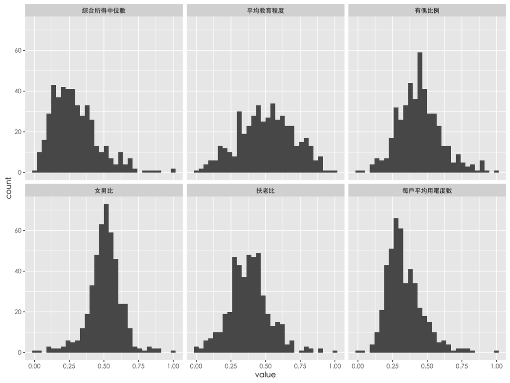

```r
tmp2 %>%
  ggplot(aes(x=value)) +
  geom_histogram() +
  theme_grey(base_family = 'STHeiti') +
  facet_wrap( ~ index, ncol = 3, nrow = 2)
```

## 偏態對[0,1]標準化的影響

我們也發現到，變數有偏態的情形時，會對於雷達圖的呈現也些許的影響。

以`每戶平均用電度數`為例，大於0.5的資料僅佔10%(49/456)，即便小於0.5還是代表用電量高的一群，如：雖然雷達圖上顯示在0.4 ~ 0.5之間，但還是屬於高用電量的一群。

因此，透過EDA發現有右偏分布的變數，我們可以取`log`的方式給予調整。

- 扶老比_log
- 綜合所得中位數_log
- 每戶平均用電度數_log

看起來雖然還是沒有完全對稱，但是不是已經好多了？

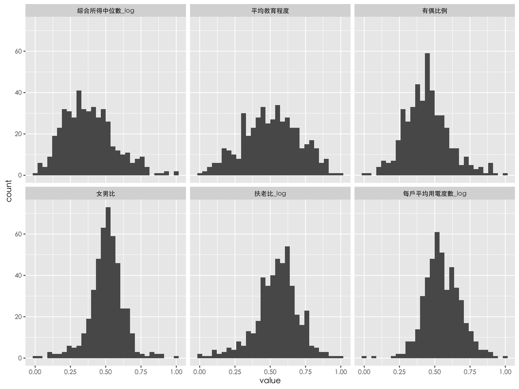

```r
data %>%
  filter(統計年月 == c(10407)) %>%
  select(行政區域,每戶平均用電度數,
         女性比例, 男性比例,
         少年人口比例,青年人口比例,壯年人口比例,老年人口比例,總人數,有偶人數,
         綜合所得中位數, 大學以上比例, 大學比例, 大學以下比例) %>%
  mutate(扶老比_log = log10((1-青年人口比例-壯年人口比例-少年人口比例)/(青年人口比例+壯年人口比例)),
         有偶比例 = 有偶人數/((1-少年人口比例)*總人數),
         平均教育程度 = 大學以上比例*6+大學比例*4+大學以下比例*0,
         女男比 = round(女性比例/男性比例,4),
         綜合所得中位數_log = log10(綜合所得中位數),
         每戶平均用電度數_log = log10(每戶平均用電度數)) %>%
  select(行政區域,綜合所得中位數_log,平均教育程度,有偶比例,女男比,扶老比_log,每戶平均用電度數_log) %>%
  mutate_each(funs(scale(.)),-行政區域) %>%
  gather('index','value',-行政區域) %>%
  group_by(index) %>%
  mutate(value = (value-min(value))/(max(value)-min(value))) %>%
  ggplot(aes(x=value)) +
  geom_histogram() +
  theme_grey(base_family = 'STHeiti') +
  facet_wrap(~index)
```